# Solution to Homework 2

Stats 531, Winter 2016

**Question 2.1**.

A. Since $\{\epsilon_{n}\}$ is white noise with variance $\sigma^{2}$, then

$$\begin{eqnarray}
\gamma_{h}&=& {\mathrm{Cov}}(X_{n},\ X_{n+h})\\
&=& {\mathrm{Cov}}(X_{n},\phi X_{n+h-1}+\epsilon_{n+h})\\
&=&\phi\mathrm{{\mathrm{Cov}}}(X_{n},\ X_{n+h-1})+ {\mathrm{Cov}}(X_{n},\ \epsilon_{n+h})\\
&=&\phi\gamma_{h-1}.
\end{eqnarray}$$

We can get $\gamma_{0}$ by simple computing,

$$\begin{eqnarray}
\gamma_{0}&=& {\mathrm{Cov}}(X_{n},\ X_{n})\\
\gamma_{0}&=& {\mathrm{Cov}}(\phi X_{n-1}+\epsilon_{n},\ \phi X_{n-1}+\epsilon_{n})\\
\gamma_{0}&=&\phi^{2} {\mathrm{Cov}}(X_{n-1},\ X_{n-1})+ {\mathrm{Cov}}(\epsilon_{n},\ \epsilon_{n})\\
\gamma_{0}&=&\phi^{2}\gamma_{0}+\sigma^{2}\\
(1\ -\phi^{2})\gamma_{0}&=&\sigma^{2}\\
\gamma_{0}&=&\frac{\sigma^{2}}{1-\phi^{2}}
\end{eqnarray}$$

Let $\gamma_{h}=A\lambda^{h}$, then

$$\begin{eqnarray}
A\lambda^{h}&=&\phi\mathrm{R}\lambda^{h-1}\\
\lambda^{h}&=&\phi\lambda^{h-1}\\
\lambda&=&\phi.
\end{eqnarray}$$

Applying $\gamma_{0}$ as an initial condition, then

$$\begin{eqnarray}
A\ \lambda^{0}&=&\gamma_{0}\\
&=&\frac{\sigma^{2}}{1-\phi^{2}}.
\end{eqnarray}$$
Therefore, $\gamma_{h}=\frac{\sigma^{2}}{1-\phi^{2}}\phi^{h}.$

B. By Taylor series expansion,

$$g(x)=g(0)+g^\prime(0)x + \frac{1}{2}g^{(2)}(0)x^{2}+\frac{1}{3!}g^{(3)}(0)x^{3}+...$$
Since $\begin{eqnarray} g^{(n)}(0)&=&\frac{d^{n}}{dt^{n}}\frac{1}{1-\phi x}\\ &=&n!\phi^{n}x^{n}, \end{eqnarray}$ we have $g(x)\ =\sum_{n=0}^{\infty}\phi^{n}x^{n}$ The AR(1) model is equivalent to the following MA $(\infty)$ process $\begin{eqnarray} X_{n}&=&\phi X_{n-1}+\epsilon_{n}\\ &=&\phi BX_{n}+\epsilon_{n}\\ (1-\phi B)X_{n}&=&\epsilon_{n}\\ X_{n}&=&(1-\phi B)^{-1}\epsilon_{n}\\ &=&\epsilon_{n}+\phi B\epsilon_{n}+\phi^{2} B^2\epsilon_{n}+...\\ &=&\epsilon_{n}+\phi\epsilon_{n-1}+\phi^{2}\epsilon_{n-2}+...\\ &=&\sum_{j=0}^{\infty}\phi^{j}\epsilon_{n-j}. \end{eqnarray}$

Then, apply the general formular for the autocovariance function of the MA $(\infty)$ process with the constraint $-1<\phi<1$,

$$\begin{eqnarray}
\gamma_{h}&=&\sum_{j=0}^{\infty}\psi_{j}\psi_{j+h}\sigma^{2}\\
&=&\sum_{j=0}^{\infty}\phi^{2j+h}\sigma^{2}\\
&=&\phi^{h}\sigma^{2}\sum_{j=0}^{\infty}\phi^{2j}\\
&=&\frac{\phi^{h}\sigma^{2}}{1-\phi^{2}}.
\end{eqnarray}$$

which is the same as the answer in A.

C. From the above derivation, we have

$$\begin{eqnarray}
\rho_{h}&=&\frac{\gamma_{h}}{\gamma_{0}}\\
&=&\frac{\frac{\phi^{h}\sigma^{2}}{1-\phi^{2}}}{\frac{\sigma^{2}}{1-\phi^{2}}}\\
&=&\phi^{h}
\end{eqnarray}$$

which is the same as R funtion ARMAacf by the following code.

```r
set.seed(12345)
ar_coefs <- 0.6
phi <-ar_coefs
acf <- phi^(0:100)
Racf <- ARMAacf(ar=ar_coefs,lag.max=100)
all(abs(acf-Racf)<1e-6)
```

```
## [1] TRUE
```

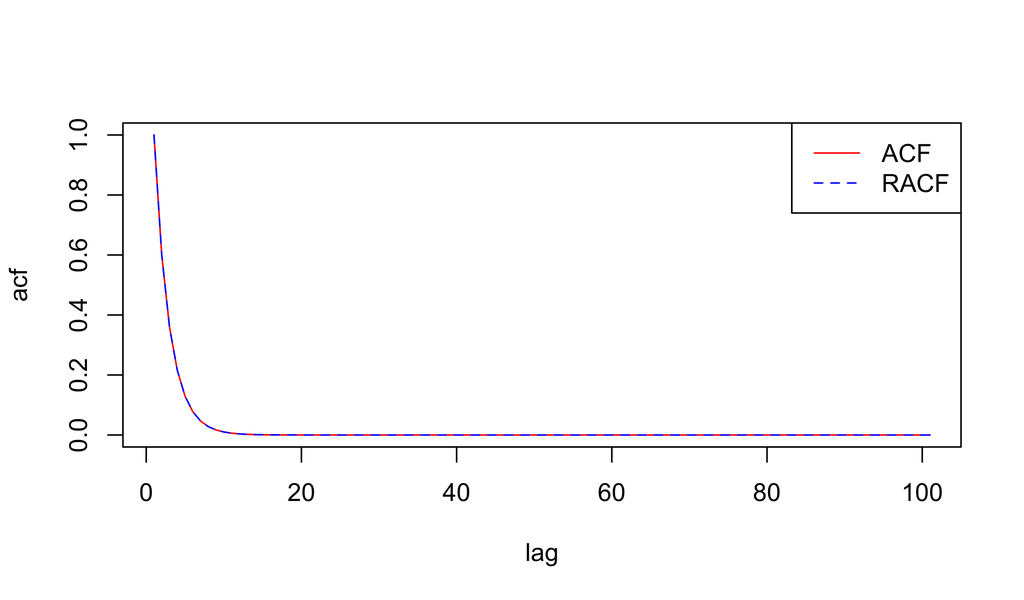

```r
plot(acf,type="l", col='red', xlab ="lag")
lines(Racf, lty =2, col='blue')
legend("topright", legend = c("ACF", "RACF"), col = c("red","blue"), lty =c(1,2))
```

**Question 2.2**.  
The solution of stochastic difference equation of the random walk model is:

$$X_{n}=\sum_{k=1}^{n}\epsilon_{k}$$
Therefore, $\begin{eqnarray} \gamma_{mn}&=&\mathrm{Cov}(X_{m},X_{n})\\ &=&{\mathrm{Cov}}\left(\sum_{i=1}^{n}\epsilon_{i},\sum_{j=1}^{n}\epsilon_{j}\right)\\ &=&\sum_{i=1}^{\min(m,n)}{\mathrm{Var}}(\epsilon_{i})\\ &=&\min(m,n)\sigma^{2} \end{eqnarray}$

Putting together, we have,

$${\gamma_{mn}=\min(m,n)\sigma^{2}}$$